# Comparative Analysis of Regression Model Performance for Coffee Adulteration Quantification Using Hyperspectral Imaging: Impact of Preprocessing and Variable Selection

Author

Derick Malavi

## Introduction

This document evaluates the performance of various regression models in detecting Arabica coffee adulteration with Robusta. The analysis focuses on key factors affecting model performance, including:

```
- The type of regression model used.
- Variable or wavelength selection methods, such as Boruta and Genetic Algorithms (GA).
- The impact of spectral preprocessing techniques.
```

The models evaluated in this study include Partial Least Squares (PLS), Least Absolute Shrinkage and Selection Operator (LASSO), Ridge Regression, Elastic Net, and ensemble methods. The ensemble models were constructed using a stacking approach, where PLS, LASSO, and Elastic Net served as base learners, and Random Forest was employed as the meta-learner. Model performance was assessed using Root Mean Squared Error (RMSE) values for the test set and Residual Predictive Deviation (RPD) to evaluate predictive accuracy and reliability.

## Load Packages

```r
suppressWarnings(suppressMessages({
  library(readxl)
  library(readr)
  library(tidyverse)
  library(car)
  library(PMCMRplus)
  library(ggplot2)
  library(tidyr)
  library(skimr)
  library(janitor)
  library(lattice)
  library(dunn.test)
  library(ARTool)
  library(emmeans)
}))
```

## Part 1: Assess Model Performance (External Validation Set): Based on type of model, variable selection & spectral pre-processing

## Load and Visualize Data

```r
df <- read_excel('summary_model_results_regression_ground _coffee.xlsx')

head(df)
```

```
# A tibble: 6 × 5
  Model Pre_processing Variable_Selection RMSEP   RPD
  <chr> <chr>          <chr>              <dbl> <dbl>
1 PLS   Unprocessed    None                8.19  3.56
2 PLS   SNV+SG+1D      None                8.86  3.29
3 PLS   SNV+SG+2D      None                7.7   3.78
4 PLS   MSC+SG+1D      None                8.85  3.29
5 PLS   MSC+SG+2D      None                9     3.24
6 LASSO Unprocessed    None               11.6   2.51
```

```r
# Change the independent variables to factors

df$Model <- as.factor(df$Model)
df$Pre_processing <- as.factor(df$Pre_processing)
df$Variable_Selection <- as.factor(df$Variable_Selection)

# column names
colnames(df)
```

```
[1] "Model"              "Pre_processing"     "Variable_Selection"
[4] "RMSEP"              "RPD"
```

## Check Distribution Using Histograms

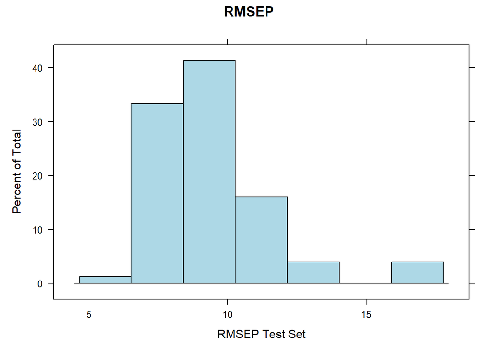

```r
histogram(df$RMSEP,
          main = 'RMSEP', xlab = 'RMSEP Test Set',
          cex.main = 1,col = 'lightblue')
```

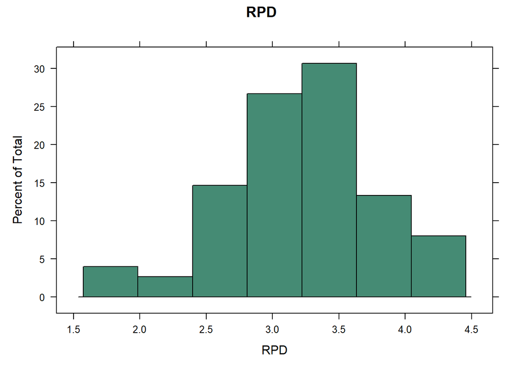

```r
histogram(~RPD, data = df,
          main = 'RPD',xlab = 'RPD',
          cex.main = 0.4, col = 'aquamarine4')
```

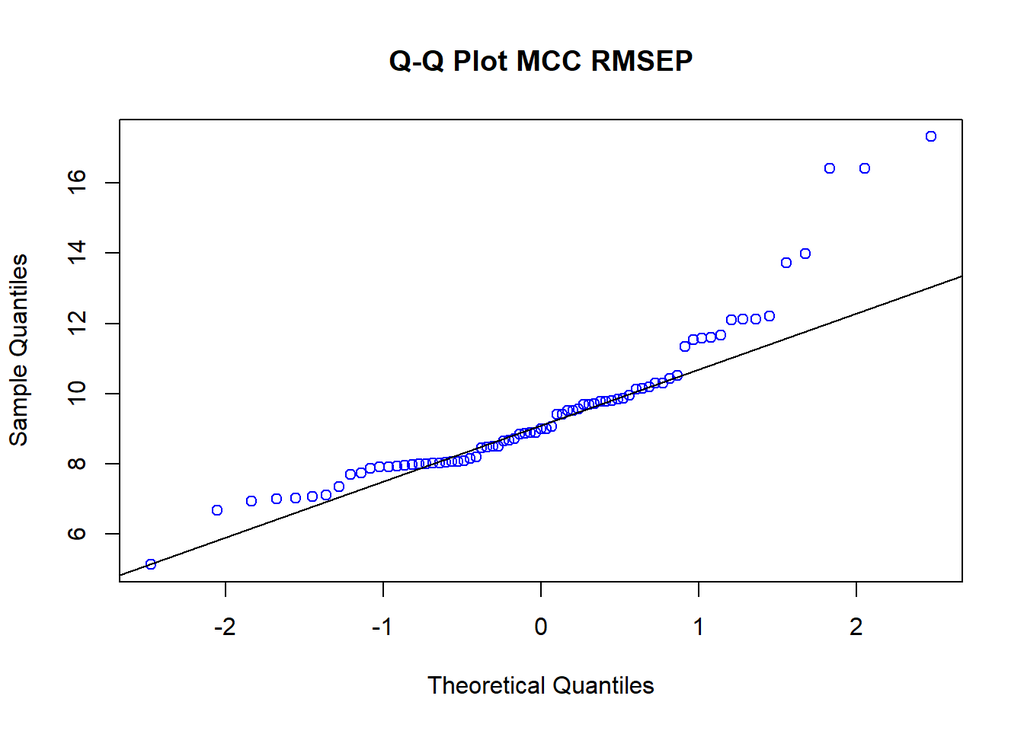

```r
qqnorm(df$RMSEP,
       main = 'Q-Q Plot MCC RMSEP', col = "blue")
qqline(df$RMSEP)
```

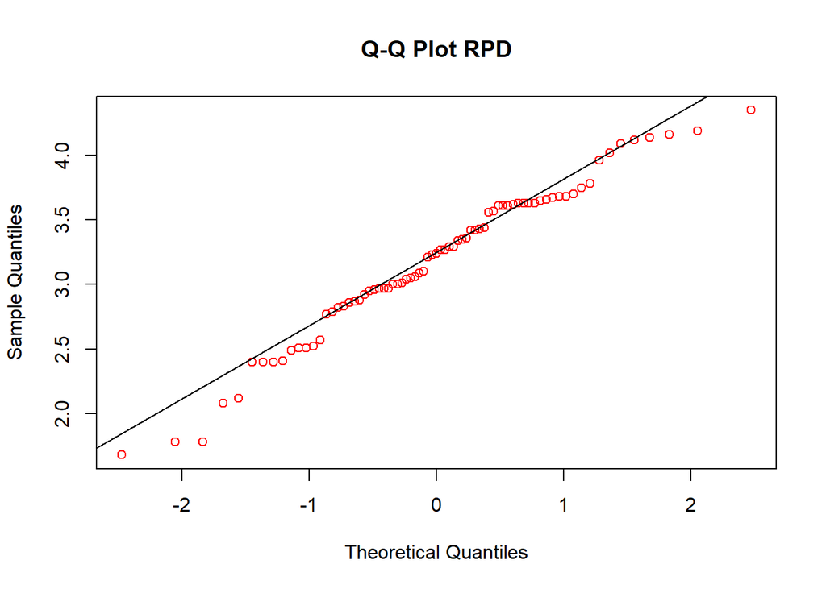

```r
qqnorm(df$RPD,
       main = 'Q-Q Plot RPD', col = "red")
qqline(df$RPD)
```

- Based on the histograms and quantile plots, the RMSEP data does not appear to be normally distributed. This can be verified further by the **Shapiro- Wilke Test**.

## Test for Normality

```r
shapiro.test(df$RMSEP)
```

```
    Shapiro-Wilk normality test

data:  df$RMSEP
W = 0.87695, p-value = 2.775e-06
```

```r
shapiro.test(df$RPD)
```

```
    Shapiro-Wilk normality test

data:  df$RPD
W = 0.97436, p-value = 0.1317
```

```r
# RPD is normally distibuted
```

```r
# Run ANOVA and check the normality of residuals
aov_model_1 <- aov(RMSEP~Model, data = df)

# Check assumptions
shapiro.test(residuals(aov_model_1))  # Normality
```

```
    Shapiro-Wilk normality test

data:  residuals(aov_model_1)
W = 0.95539, p-value = 0.009957
```

```r
leveneTest(RMSEP~Model, data = df)  # Variance homogeneity
```

```
Levene's Test for Homogeneity of Variance (center = median)
      Df F value   Pr(>F)
group  4  4.2836 0.003702 **
      70
---
Signif. codes:  0 '***' 0.001 '**' 0.01 '*' 0.05 '.' 0.1 ' ' 1
```

```r
colnames(df)
```

```
[1] "Model"              "Pre_processing"     "Variable_Selection"
[4] "RMSEP"              "RPD"
```

- The results of the Shapiro-Wilk test (for the residuals) are statistically significant (p < 0.05), providing strong evidence against the assumption of normality. This indicates that the data are not normally distribute. We will therefore consider non-parametric alternatives for RMSEP!

## Check Performance based on Type of Model

- This section investigates the models PLS, LASSO, Ridge, Elastic Net and stacked models

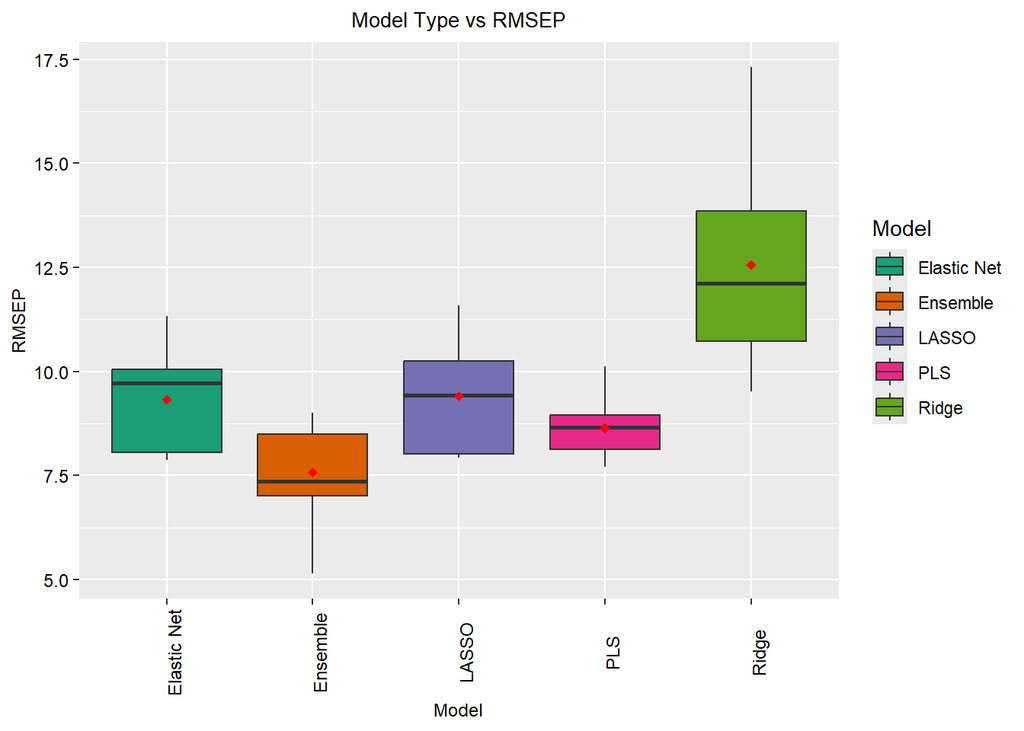

```r
# Visualize with box plots for RMSEP


ggplot(data = df, aes(x = Model, y = RMSEP))+
  geom_boxplot(aes(fill = Model))+
  labs(title = 'Model Type vs RMSEP')+
  theme(axis.title.x = element_text(color = "black",size= 9),
        axis.text.x = element_text(color = "black", angle = 90, size= 9),
        axis.text.y = element_text(color = "black",size =9),
        axis.title.y = element_text(color = "black",size =9),
        plot.title = element_text(hjust = 0.5, color = 'black', size = 10))+
  scale_fill_brewer(palette = "Dark2")+
  stat_summary(fun=mean, geom="point", shape=18, size=2, color="red")
```

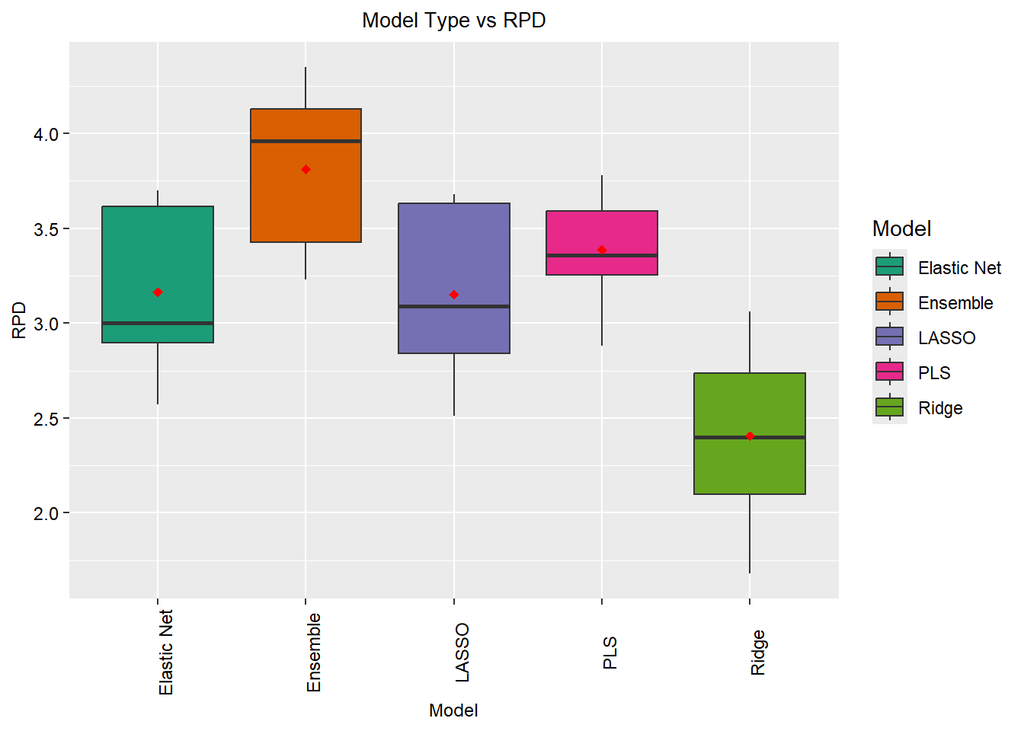

```r
# Visualize with box plots for RPD

ggplot(data = df, aes(x = Model, y = RPD))+
  geom_boxplot(aes(fill = Model))+
  labs(title = 'Model Type vs RPD')+
  theme(axis.title.x = element_text(color = "black",size= 9),
        axis.text.x = element_text(color = "black", angle = 90, size= 9),
        axis.text.y = element_text(color = "black",size =9),
        axis.title.y = element_text(color = "black",size =9),
        plot.title = element_text(hjust = 0.5, color = 'black', size = 10))+
  scale_fill_brewer(palette = "Dark2")+
  stat_summary(fun=mean, geom="point", shape=18, size=2, color="red")
```

### Perform Kruskall-Wallis Test for Model Types

#### Based on RMSEP

```r
kruskal.test(RMSEP~Model, data= df)
```

```
    Kruskal-Wallis rank sum test

data:  RMSEP by Model
Kruskal-Wallis chi-squared = 40.014, df = 4, p-value = 4.3e-08
```

- There is statistical difference in performance for models trained with unbalanced data. We will examine the differences using the **Dunn Test** and **Bonferroni correction**, and later by GLM.

#### Checking for differences in RMSEP based on the type of models

```r
dunn.test(df$RMSEP, df$Model, method = 'bonferroni')
```

```
  Kruskal-Wallis rank sum test

data: x and group
Kruskal-Wallis chi-squared = 40.0139, df = 4, p-value = 0

                           Comparison of x by group
                                 (Bonferroni)
Col Mean-|
Row Mean |   Elastic    Ensemble      LASSO        PLS
---------+--------------------------------------------
Ensemble |   3.196059
         |    0.0070*
   LASSO |   0.108908  -3.087150
         |     1.0000    0.0101*
     PLS |   1.210565  -1.985494   1.101656
         |     1.0000     0.2354     1.0000
   Ridge |  -2.965675  -6.161735  -3.074584  -4.176240
         |    0.0151*    0.0000*    0.0105*    0.0001*

alpha = 0.05
Reject Ho if p <= alpha/2
```

- Ensemble methods yield significantly lower RMSEP compared to LASSO, ELastoc Net and Ridge Regression.On the other hand, Ridge regression gives higher RMSEP values in comparison to the rest of the models. There is no significant difference in performance among the models PLS, Elastic Net and LASSO.

### Perform ANOVA based on RPD

```r
anova_results_model <- aov(RPD~Model, data = df)
summary(anova_results_model)
```

```
            Df Sum Sq Mean Sq F value   Pr(>F)
Model        4  15.66   3.914   26.23 2.63e-13 ***
Residuals   70  10.44   0.149
---
Signif. codes:  0 '***' 0.001 '**' 0.01 '*' 0.05 '.' 0.1 ' ' 1
```

- There is a significant difference in model performance based on RPD values.

### Check the differences in RPD for the model types

```r
TukeyHSD(anova_results_model)
```

```
  Tukey multiple comparisons of means
    95% family-wise confidence level

Fit: aov(formula = RPD ~ Model, data = df)

$Model
                            diff        lwr         upr     p adj
Ensemble-Elastic Net  0.64733333  0.2523818  1.04228491 0.0001807
LASSO-Elastic Net    -0.01333333 -0.4082849  0.38161824 0.9999815
PLS-Elastic Net       0.22333333 -0.1716182  0.61828491 0.5128992
Ridge-Elastic Net    -0.75933333 -1.1542849 -0.36438176 0.0000090
LASSO-Ensemble       -0.66066667 -1.0556182 -0.26571509 0.0001280
PLS-Ensemble         -0.42400000 -0.8189516 -0.02904842 0.0292304
Ridge-Ensemble       -1.40666667 -1.8016182 -1.01171509 0.0000000
PLS-LASSO             0.23666667 -0.1582849  0.63161824 0.4540581
Ridge-LASSO          -0.74600000 -1.1409516 -0.35104842 0.0000130
Ridge-PLS            -0.98266667 -1.3776182 -0.58771509 0.0000000
```

- Ensemble method yield a significantly higher RPD compared to Elastic Net, Lasso & Ridge Regressions.
- Ridge regression shows significantly lower performance as compared to the rest of the models.

## Check Performance based on Variable Selection

- The models were trained using the full spectra (224 variables) and feature selection methods, including Genetic Algorithm, Recursive Feature Elimination, and Boruta.

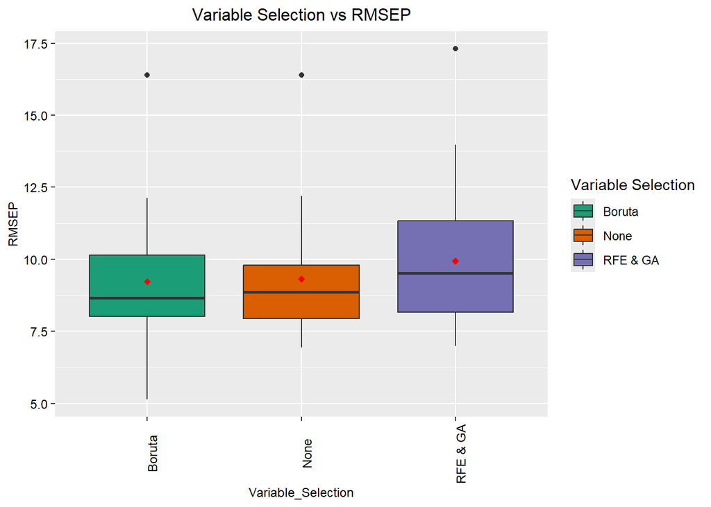

```r
# Visualize with box plots RMSEP

df %>% ggplot(aes(x = Variable_Selection, y = RMSEP))+
  geom_boxplot(aes(fill = Variable_Selection))+
  labs(title = 'Variable Selection vs RMSEP')+
  theme(axis.title.x = element_text(color = "black",size= 9),
        axis.text.x = element_text(color = "black", angle = 90, size= 9),
        axis.text.y = element_text(color = "black",size =9),
        axis.title.y = element_text(color = "black",size =9),
        plot.title = element_text(hjust = 0.5, color = 'black', size = 12))+
  scale_fill_brewer(palette = "Dark2", name = 'Variable Selection')+
  stat_summary(fun=mean, geom="point", shape=18, size=2, color="red")
```

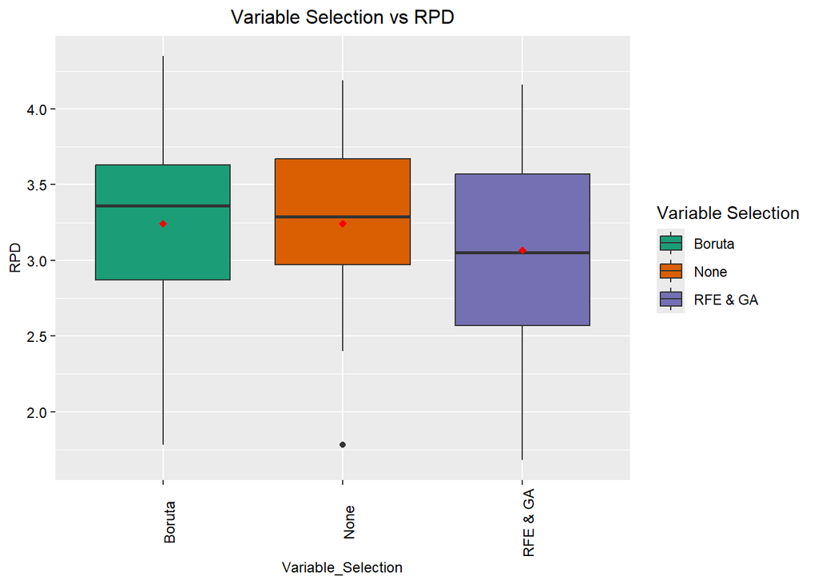

```r
# Visualize with box plots

df %>% ggplot(aes(x = Variable_Selection, y = RPD))+
  geom_boxplot(aes(fill = Variable_Selection))+
  labs(title = 'Variable Selection vs RPD')+
  theme(axis.title.x = element_text(color = "black",size= 9),
        axis.text.x = element_text(color = "black", angle = 90, size= 9),
        axis.text.y = element_text(color = "black",size =9),
        axis.title.y = element_text(color = "black",size =9),
        plot.title = element_text(hjust = 0.5, color = 'black', size = 12))+
  scale_fill_brewer(palette = "Dark2", name = 'Variable Selection')+
  stat_summary(fun=mean, geom="point", shape=18, size=2, color="red")
```

### Perform Kruskall-Wallis Test for Variable Selection

#### Check on RMSEP

```r
kruskal.test(RMSEP~Variable_Selection, data= df)
```

```
    Kruskal-Wallis rank sum test

data:  RMSEP by Variable_Selection
Kruskal-Wallis chi-squared = 1.3417, df = 2, p-value = 0.5113
```

### Check on RPD

```r
anova_results_var_selection <- aov(RPD~Variable_Selection, data= df)
print(summary(anova_results_var_selection))
```

```
                   Df Sum Sq Mean Sq F value Pr(>F)
Variable_Selection  2  0.521  0.2605   0.733  0.484
Residuals          72 25.580  0.3553
```

- There is no statistically significant difference in model performance based on variable selection methods (p > 0.05). This indicates that these techniques effectively identify variables or regions with useful information without compromising model performance. This will, however, be investigated further by General Linear Model (GLM).

## Check Performance based on spectral preprocessing methods

- The hyperspectral imaging spectra were pre-processed using various techniques, including Standard Normal Variate (SNV) and Multiplicative Scatter Correction (MSC), combined with Savitzky-Golay filtering and derivatives. Unprocessed spectra were used as the baseline for comparison.

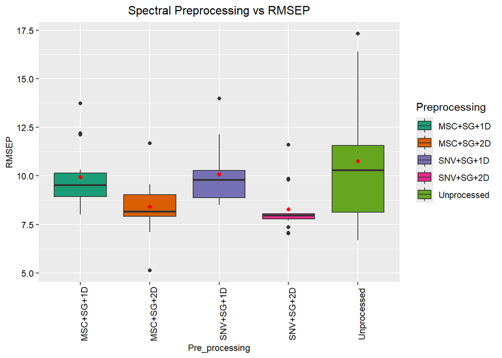

```r
# Visualize with box plots

df %>% ggplot(aes(x = Pre_processing, y = RMSEP))+
  geom_boxplot(aes(fill = Pre_processing))+
  labs(title = 'Spectral Preprocessing vs RMSEP')+
  theme(axis.title.x = element_text(color = "black",size= 9),
        axis.text.x = element_text(color = "black", angle = 90, size= 9),
        axis.text.y = element_text(color = "black",size =9),
        axis.title.y = element_text(color = "black",size =9),
        plot.title = element_text(hjust = 0.5, color = 'black', size = 12))+
  scale_fill_brewer(palette = "Dark2", name = 'Preprocessing')+
  stat_summary(fun=mean, geom="point", shape=18, size=2, color="red")
```

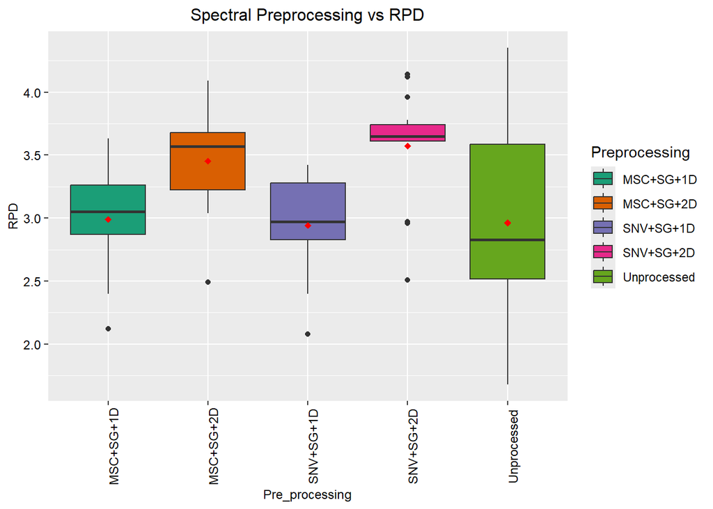

```r
# Visualize with box plots

df %>% ggplot(aes(x = Pre_processing, y = RPD))+
  geom_boxplot(aes(fill = Pre_processing))+
  labs(title = 'Spectral Preprocessing vs RPD')+
  theme(axis.title.x = element_text(color = "black",size= 9),
        axis.text.x = element_text(color = "black", angle = 90, size= 9),
        axis.text.y = element_text(color = "black",size =9),
        axis.title.y = element_text(color = "black",size =9),
        plot.title = element_text(hjust = 0.5, color = 'black', size = 12))+
  scale_fill_brewer(palette = "Dark2", name = 'Preprocessing')+
  stat_summary(fun=mean, geom="point", shape=18, size=2, color="red")
```

### Perform Kruskall-Wallis Test for Spectral Preprocessing Techniques (RMSEP)

```r
kruskal.test(RMSEP~Pre_processing, data= df)
```

```
    Kruskal-Wallis rank sum test

data:  RMSEP by Pre_processing
Kruskal-Wallis chi-squared = 19.202, df = 4, p-value = 0.0007171
```

- Spectral preprocessing significantly (p < 0.05) influences the performance of models (based on RMSEP)

#### Checking for differences in pre-processing techniques

```r
dunn.test(df$RMSEP, df$Pre_processing, method = 'bonferroni')
```

```
  Kruskal-Wallis rank sum test

data: x and group
Kruskal-Wallis chi-squared = 19.2025, df = 4, p-value = 0

                           Comparison of x by group
                                 (Bonferroni)
Col Mean-|
Row Mean |   MSC+SG+1   MSC+SG+2   SNV+SG+1   SNV+SG+2
---------+--------------------------------------------
MSC+SG+2 |   2.450452
         |     0.0713
SNV+SG+1 |  -0.314160  -2.764612
         |     1.0000     0.0285
SNV+SG+2 |   2.994997   0.544544   3.309157
         |    0.0137*     1.0000    0.0047*
Unproces |   0.104720  -2.345732   0.418880  -2.890276
         |     1.0000     0.0949     1.0000    0.0192*

alpha = 0.05
Reject Ho if p <= alpha/2
```

- There is a statistically significant improvement when using SNV+SG+2 over MSC+SG+1
- SNV+SG+2 shows a significant improvement over SNV+SG+1.
- SNV+SG+2 shows a significant improvement over the Unprocessed approach.

### Perform One-way ANOVA Test for Spectral Preprocessing Techniques (RPD)

```r
anova_results_preprocessing <- aov(RPD~Pre_processing, data = df)

summary(anova_results_preprocessing)
```

```
               Df Sum Sq Mean Sq F value  Pr(>F)
Pre_processing  4  5.509  1.3771   4.681 0.00209 **
Residuals      70 20.592  0.2942
---
Signif. codes:  0 '***' 0.001 '**' 0.01 '*' 0.05 '.' 0.1 ' ' 1
```

- The results indicate that spectral preprocessing influence model performance based on RPD.

#### Check the differences in performance (RPD) & spectral preprocessing

```r
TukeyHSD(anova_results_preprocessing)
```

```
  Tukey multiple comparisons of means
    95% family-wise confidence level

Fit: aov(formula = RPD ~ Pre_processing, data = df)

$Pre_processing
                             diff         lwr         upr     p adj
MSC+SG+2D-MSC+SG+1D    0.46066667 -0.09390089  1.01523423 0.1489534
SNV+SG+1D-MSC+SG+1D   -0.04866667 -0.60323423  0.50590089 0.9991752
SNV+SG+2D-MSC+SG+1D    0.58133333  0.02676577  1.13590089 0.0352945
Unprocessed-MSC+SG+1D -0.02866667 -0.58323423  0.52590089 0.9998988
SNV+SG+1D-MSC+SG+2D   -0.50933333 -1.06390089  0.04523423 0.0868596
SNV+SG+2D-MSC+SG+2D    0.12066667 -0.43390089  0.67523423 0.9731772
Unprocessed-MSC+SG+2D -0.48933333 -1.04390089  0.06523423 0.1091894
SNV+SG+2D-SNV+SG+1D    0.63000000  0.07543244  1.18456756 0.0180372
Unprocessed-SNV+SG+1D  0.02000000 -0.53456756  0.57456756 0.9999759
Unprocessed-SNV+SG+2D -0.61000000 -1.16456756 -0.05543244 0.0239038
```

- From the findings:
  - Models with SNV+SG+2D data yield significantly higher RPDs compared to models with MSC+SG+1D.
  - Spectral preprocessing by SNV+SG+2D also yield the best predictive models compared to SNV+SG+1D.
  - SNV+SG+2D models also outperform models from unprocessed spectra.

### Verify with General Linear Model (GLM)

#### Fit GLM-RMSEP

```r
glm_model <- glm(RMSEP ~ Model + Pre_processing + Variable_Selection,
                 data = df,
                 family = gaussian())
summary(glm_model)
```

```
Call:
glm(formula = RMSEP ~ Model + Pre_processing + Variable_Selection,
    family = gaussian(), data = df)

Coefficients:
                           Estimate Std. Error t value Pr(>|t|)
(Intercept)                 9.49587    0.41026  23.146  < 2e-16 ***
ModelEnsemble              -1.75867    0.39117  -4.496 2.98e-05 ***
ModelLASSO                  0.07067    0.39117   0.181 0.857209
ModelPLS                   -0.68667    0.39117  -1.755 0.083971 .
ModelRidge                  3.23000    0.39117   8.257 1.14e-11 ***
Pre_processingMSC+SG+2D    -1.52000    0.39117  -3.886 0.000245 ***
Pre_processingSNV+SG+1D     0.15067    0.39117   0.385 0.701387
Pre_processingSNV+SG+2D    -1.64733    0.39117  -4.211 8.10e-05 ***
Pre_processingUnprocessed   0.82200    0.39117   2.101 0.039548 *
Variable_SelectionNone      0.09480    0.30300   0.313 0.755393
Variable_SelectionRFE & GA  0.71440    0.30300   2.358 0.021453 *
---
Signif. codes:  0 '***' 0.001 '**' 0.01 '*' 0.05 '.' 0.1 ' ' 1

(Dispersion parameter for gaussian family taken to be 1.14759)

    Null deviance: 360.201  on 74  degrees of freedom
Residual deviance:  73.446  on 64  degrees of freedom
AIC: 235.27

Number of Fisher Scoring iterations: 2
```

#### Pairwise comparisons

```r
# Pairwise comparisons for Model
emmeans_model <- emmeans(glm_model, ~ Model)
pairs(emmeans_model, adjust = "bonferroni")  # Bonferroni correction
```

```
 contrast               estimate    SE df t.ratio p.value
 Elastic Net - Ensemble   1.7587 0.391 64   4.496  0.0003
 Elastic Net - LASSO     -0.0707 0.391 64  -0.181  1.0000
 Elastic Net - PLS        0.6867 0.391 64   1.755  0.8397
 Elastic Net - Ridge     -3.2300 0.391 64  -8.257  <.0001
 Ensemble - LASSO        -1.8293 0.391 64  -4.677  0.0002
 Ensemble - PLS          -1.0720 0.391 64  -2.741  0.0794
 Ensemble - Ridge        -4.9887 0.391 64 -12.753  <.0001
 LASSO - PLS              0.7573 0.391 64   1.936  0.5728
 LASSO - Ridge           -3.1593 0.391 64  -8.077  <.0001
 PLS - Ridge             -3.9167 0.391 64 -10.013  <.0001

Results are averaged over the levels of: Pre_processing, Variable_Selection
P value adjustment: bonferroni method for 10 tests
```

```r
# Pairwise comparisons for Pre_processing
emmeans_preprocessing <- emmeans(glm_model, ~ Pre_processing)
pairs(emmeans_preprocessing, adjust = "bonferroni")
```

```
 contrast                  estimate    SE df t.ratio p.value
 (MSC+SG+1D) - (MSC+SG+2D)    1.520 0.391 64   3.886  0.0024
 (MSC+SG+1D) - (SNV+SG+1D)   -0.151 0.391 64  -0.385  1.0000
 (MSC+SG+1D) - (SNV+SG+2D)    1.647 0.391 64   4.211  0.0008
 (MSC+SG+1D) - Unprocessed   -0.822 0.391 64  -2.101  0.3955
 (MSC+SG+2D) - (SNV+SG+1D)   -1.671 0.391 64  -4.271  0.0007
 (MSC+SG+2D) - (SNV+SG+2D)    0.127 0.391 64   0.326  1.0000
 (MSC+SG+2D) - Unprocessed   -2.342 0.391 64  -5.987  <.0001
 (SNV+SG+1D) - (SNV+SG+2D)    1.798 0.391 64   4.596  0.0002
 (SNV+SG+1D) - Unprocessed   -0.671 0.391 64  -1.716  0.9096
 (SNV+SG+2D) - Unprocessed   -2.469 0.391 64  -6.313  <.0001

Results are averaged over the levels of: Model, Variable_Selection
P value adjustment: bonferroni method for 10 tests
```

```r
# Pairwise comparisons for Wav_Selec_Reduction
emmeans_wave <- emmeans(glm_model, ~ Variable_Selection)
pairs(emmeans_wave, adjust = "bonferroni")
```

```
 contrast          estimate    SE df t.ratio p.value
 Boruta - None      -0.0948 0.303 64  -0.313  1.0000
 Boruta - RFE & GA  -0.7144 0.303 64  -2.358  0.0644
 None - RFE & GA    -0.6196 0.303 64  -2.045  0.1349

Results are averaged over the levels of: Model, Pre_processing
P value adjustment: bonferroni method for 3 tests
```

#### GLM RMSEP Results

- MSC+SG+2D performs significantly better than MSC+SG+1D.
- SNV+SG+2D performs significantly better than MSC+SG+1D.
- SNV+SG+1D performs significantly worse than MSC+SG+2D.
- Unprocessed data performs significantly worse than MSC+SG+2D.
- Unprocessed data performs significantly worse than SNV+SG+2D.
- There is no significant difference in performance between the variable selection methods and raw spectra.

```r
# Group by some models

Model_Means <- df %>%
  select(Model, RMSEP) %>%
  group_by(Model) %>%
  summarise(
    Mean_RMSEP = mean(RMSEP, na.rm = TRUE),
  ) %>% arrange((Mean_RMSEP))

# View the result
print(Model_Means)
```

```
# A tibble: 5 × 2
  Model       Mean_RMSEP
  <fct>            <dbl>
1 Ensemble          7.57
2 PLS               8.64
3 Elastic Net       9.33
4 LASSO             9.40
5 Ridge            12.6
```

```r
# Group Variable Selection MCC Averages
model_means_var_selec <- df %>%
  select(Variable_Selection, RMSEP) %>%
  group_by(Variable_Selection) %>%
  summarise(
    Mean_RMSEP = mean(RMSEP, na.rm = TRUE),
  ) %>% arrange((Mean_RMSEP))

print(model_means_var_selec)
```

```
# A tibble: 3 × 2
  Variable_Selection Mean_RMSEP
  <fct>                   <dbl>
1 Boruta                   9.23
2 None                     9.32
3 RFE & GA                 9.94
```

#### Fit GLM-RPD

```r
glm_model_RPD <- glm(RPD ~ Model + Pre_processing + Variable_Selection,
                 data = df,
                 family = gaussian())
summary(glm_model_RPD)
```

```
Call:
glm(formula = RPD ~ Model + Pre_processing + Variable_Selection,
    family = gaussian(), data = df)

Coefficients:
                           Estimate Std. Error t value Pr(>|t|)
(Intercept)                 3.03027    0.10059  30.126  < 2e-16 ***
ModelEnsemble               0.64733    0.09590   6.750 5.10e-09 ***
ModelLASSO                 -0.01333    0.09590  -0.139   0.8899
ModelPLS                    0.22333    0.09590   2.329   0.0230 *
ModelRidge                 -0.75933    0.09590  -7.918 4.50e-11 ***
Pre_processingMSC+SG+2D     0.46067    0.09590   4.803 9.78e-06 ***
Pre_processingSNV+SG+1D    -0.04867    0.09590  -0.507   0.6136
Pre_processingSNV+SG+2D     0.58133    0.09590   6.062 7.95e-08 ***
Pre_processingUnprocessed  -0.02867    0.09590  -0.299   0.7660
Variable_SelectionNone      0.00080    0.07429   0.011   0.9914
Variable_SelectionRFE & GA -0.17640    0.07429  -2.375   0.0206 *
---
Signif. codes:  0 '***' 0.001 '**' 0.01 '*' 0.05 '.' 0.1 ' ' 1

(Dispersion parameter for gaussian family taken to be 0.0689825)

    Null deviance: 26.1008  on 74  degrees of freedom
Residual deviance:  4.4149  on 64  degrees of freedom
AIC: 24.403

Number of Fisher Scoring iterations: 2
```

#### Pairwise comparisons

```r
# Pairwise comparisons for Model
emmeans_model_RPD <- emmeans(glm_model_RPD, ~ Model)
pairs(emmeans_model_RPD, adjust = "bonferroni")  # Bonferroni correction
```

```
 contrast               estimate     SE df t.ratio p.value
 Elastic Net - Ensemble  -0.6473 0.0959 64  -6.750  <.0001
 Elastic Net - LASSO      0.0133 0.0959 64   0.139  1.0000
 Elastic Net - PLS       -0.2233 0.0959 64  -2.329  0.2305
 Elastic Net - Ridge      0.7593 0.0959 64   7.918  <.0001
 Ensemble - LASSO         0.6607 0.0959 64   6.889  <.0001
 Ensemble - PLS           0.4240 0.0959 64   4.421  0.0004
 Ensemble - Ridge         1.4067 0.0959 64  14.667  <.0001
 LASSO - PLS             -0.2367 0.0959 64  -2.468  0.1628
 LASSO - Ridge            0.7460 0.0959 64   7.779  <.0001
 PLS - Ridge              0.9827 0.0959 64  10.246  <.0001

Results are averaged over the levels of: Pre_processing, Variable_Selection
P value adjustment: bonferroni method for 10 tests
```

```r
# Pairwise comparisons for Pre_processing
emmeans_preprocessing_RPD <- emmeans(glm_model_RPD, ~ Pre_processing)
pairs(emmeans_preprocessing_RPD, adjust = "bonferroni")
```

```
 contrast                  estimate     SE df t.ratio p.value
 (MSC+SG+1D) - (MSC+SG+2D)  -0.4607 0.0959 64  -4.803  0.0001
 (MSC+SG+1D) - (SNV+SG+1D)   0.0487 0.0959 64   0.507  1.0000
 (MSC+SG+1D) - (SNV+SG+2D)  -0.5813 0.0959 64  -6.062  <.0001
 (MSC+SG+1D) - Unprocessed   0.0287 0.0959 64   0.299  1.0000
 (MSC+SG+2D) - (SNV+SG+1D)   0.5093 0.0959 64   5.311  <.0001
 (MSC+SG+2D) - (SNV+SG+2D)  -0.1207 0.0959 64  -1.258  1.0000
 (MSC+SG+2D) - Unprocessed   0.4893 0.0959 64   5.102  <.0001
 (SNV+SG+1D) - (SNV+SG+2D)  -0.6300 0.0959 64  -6.569  <.0001
 (SNV+SG+1D) - Unprocessed  -0.0200 0.0959 64  -0.209  1.0000
 (SNV+SG+2D) - Unprocessed   0.6100 0.0959 64   6.360  <.0001

Results are averaged over the levels of: Model, Variable_Selection
P value adjustment: bonferroni method for 10 tests
```

```r
# Pairwise comparisons for Wav_Selec_Reduction
emmeans_wave_RPD <- emmeans(glm_model_RPD, ~ Variable_Selection)
pairs(emmeans_wave_RPD, adjust = "bonferroni")
```

```
 contrast          estimate     SE df t.ratio p.value
 Boruta - None      -0.0008 0.0743 64  -0.011  1.0000
 Boruta - RFE & GA   0.1764 0.0743 64   2.375  0.0617
 None - RFE & GA     0.1772 0.0743 64   2.385  0.0601

Results are averaged over the levels of: Model, Pre_processing
P value adjustment: bonferroni method for 3 tests
```

- MSC+SG+2D performs significantly better than MSC+SG+1D.
- SNV+SG+2D performs significantly better than MSC+SG+1D.
- SNV+SG+1D performs significantly worse than MSC+SG+2D.
- Unprocessed data performs significantly worse than MSC+SG+2D.
- Unprocessed data performs significantly worse than SNV+SG+2D.
- Ensemble models outperform other models.
- Poor performance is exhibited by Ridge Regression
- There is no significant difference in performance between the variable selection methods and raw spectra (based on RPD).

```r
# Group by some models

Model_Means_RPD <- df %>%
  select(Model, RPD) %>%
  group_by(Model) %>%
  summarise(
    Mean_RPD = mean(RPD, na.rm = TRUE),
  ) %>% arrange(desc(Mean_RPD))

# View the result
Model_Means_RPD
```

```
# A tibble: 5 × 2
  Model       Mean_RPD
  <fct>          <dbl>
1 Ensemble        3.81
2 PLS             3.39
3 Elastic Net     3.16
4 LASSO           3.15
5 Ridge           2.41
```